# Distribution Free Methods: Introduction

## Readings

North BV, Curtis D, Sham PC. (2002). A note on the calculation of empirical P values from Monte Carlo procedures. *Am J Hum Genet* 71:439-441.

## Additional Resources

- Ludbrook J, Dudley H. (1998). Why Permutation Tests Are Superior to t and F Tests in Biomedical Research. Am Stat 52:127–132.
- Manly BFJ. (2006). *Randomization, Bootstrap and Monte Carlo Methods in Biology*. 3rd edition. Boca Raton, FL: Chapman and Hall/CRC.
- Roff DA. (2006). *Introduction to Computer-intensive Methods of Data Analysis in Biology*. Cambridge University Press.

## Distribution Free Methods

Distribution free methods do not assume the data are drawn from any specific probability distribution. *Important: distribution-free, not assumption-free (e.g., IID).*

- Randomization
  - Shuffle data set in some way
- Resampling
  - Sample from data set in some way
    - Jackknife
    - Bootstrap

## Why distribution free methods?

- Real data often does not follow standard distributions
- Very flexible
- Uses only information from your data set
  - Good & Bad
- Standard errors can not always be calculated for all parameters

## Resampling

- Primarily a method for parameter estimation and interval estimation
- Sample from the data to estimate the variability in the parameter estimate
- **Assumption:** Observed distribution is representative of the true distribution
- Need to empirically show the method works for each type of application using simulation

## Resampling procedure: bootstrap

> Bootstrap: Sample N observations with replacement, estimate parameter, repeat k times

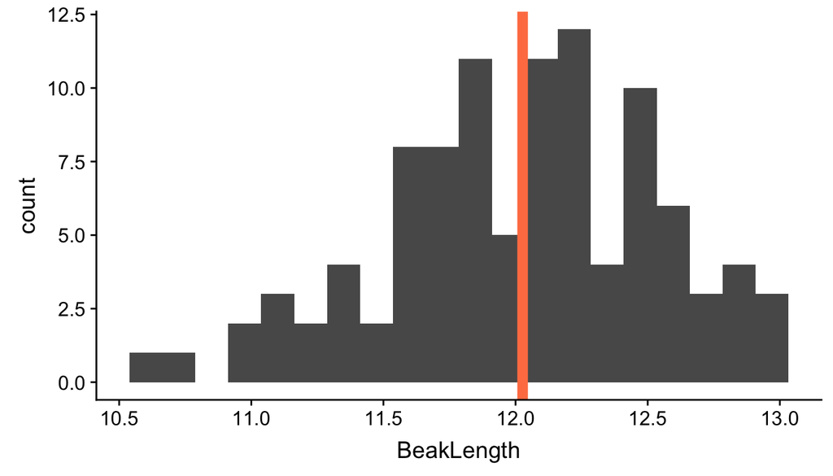

## Resampling procedure: bootstrap

- Sample with replacement, n = number of observations

```
## 11.81186 11.73618 12.21244 12.02097 11.06107 11.88257 ...
```

- Get mean of sample (& repeat):

```
## [1] 11.97294
```

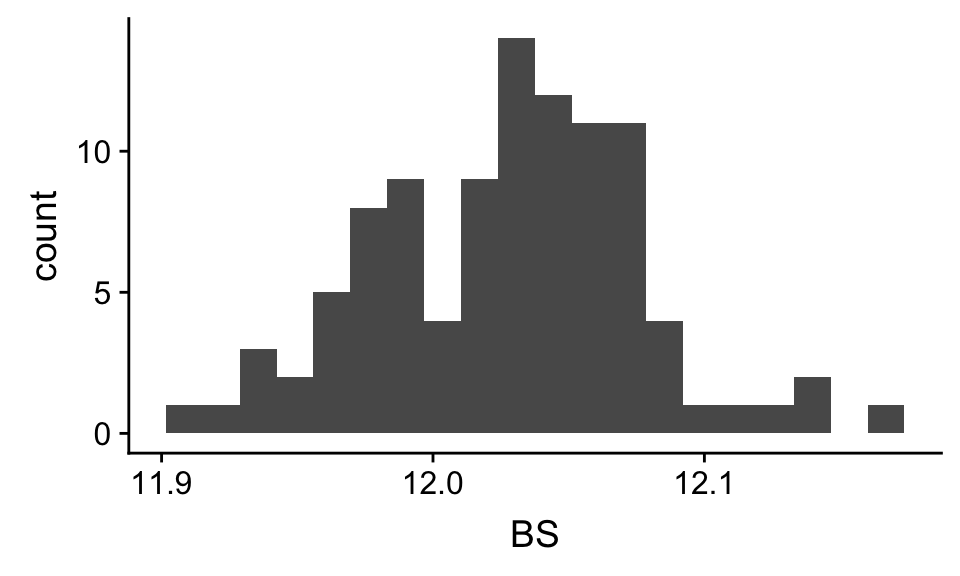

## Resampling procedure: bootstrap

- Estimate of mean = mean of the bootstrap estimates
- Estimate of SE = standard deviation of the bootstrap estimates

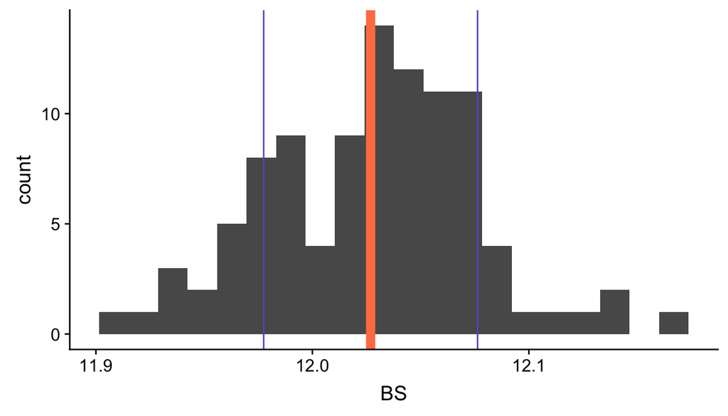

## Resampling procedure: jackknife

> Jackknife: Remove 1 observation, estimate parameter, repeat for each observation in the data set, removing each exactly once.

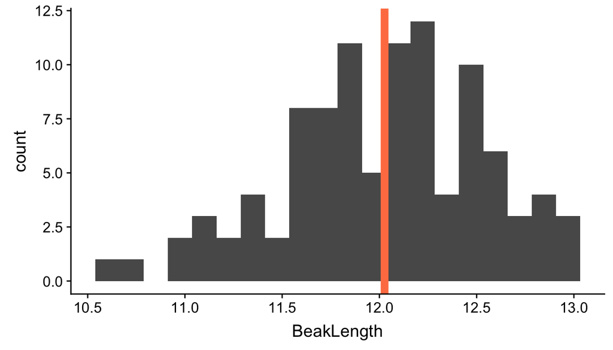

## Resampling procedure: jackknife

```
## Obs: 11.837 12.60172 12.04552 11.06107 12.78254 11.55177 ...
```

```
##          X    12.60172 12.04552 11.06107 12.78254 11.55177 ...
```

```
##       11.837     X     12.04552 11.06107 12.78254 11.55177 ...
```

```
## ....
```

## Applications & Resources: Resampling

1. Bootstrapping in phylogenetics: Sample character vectors, construct best tree, repeat. (Felsenstein 1985; Felsenstein and Kishino 1993)
2. Jackknifing in quantitative genetics (Roff and Preziozi 1994; Roff 2002, 2008)

## Randomization

- Primarily a method for hypothesis testing
- More directly asks: What is the probability of observing a result as extreme or more than my observed result?

**Assumption:** Under the null hypothesis, observations are random draws from a common population

## Randomization procedure

1. Decide on a test statistic
2. Calculate the test statistic for the *observed* data
3. Randomly shuffle the observations
4. Calculate the test statistic for that group
5. Repeat thousands of times
6. Determine the proportion of random combinations resulting in a test statistic more extreme than the observed value (“empirical *P*”)

When test assumptions are met, the results will match asymptotic procedures. When the assumptions are not met, the results will be valid.

## Decide on a test statistic

1. Mean difference
2. *t*: *t*-test, linear model parameter estimate (slope, intercept)
3. *F*: ANOVA-like
4. \(\chi^2\)
5. Any metric of your choice (P-value, Fst, heterozygosity, LOD score, etc.)

## Randomization procedure

```
## Mean A: 12.00131
## Mean B: 13.60293
```

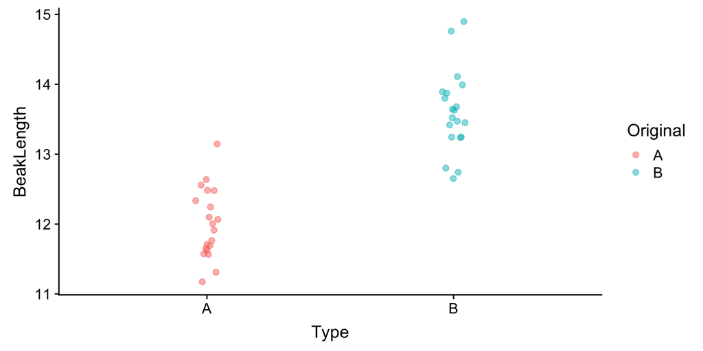

## Randomization procedure

Shuffle Type

```
## Mean A: 13.07462
## Mean B: 12.52962
```

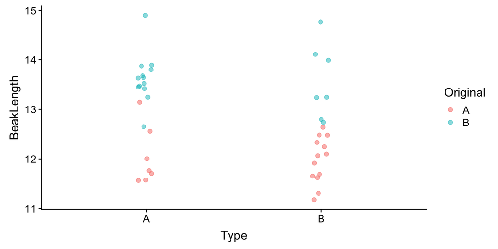

## Randomization procedure

Repeat N times

```
## Mean A: 12.5438
## Mean B: 13.06044
```

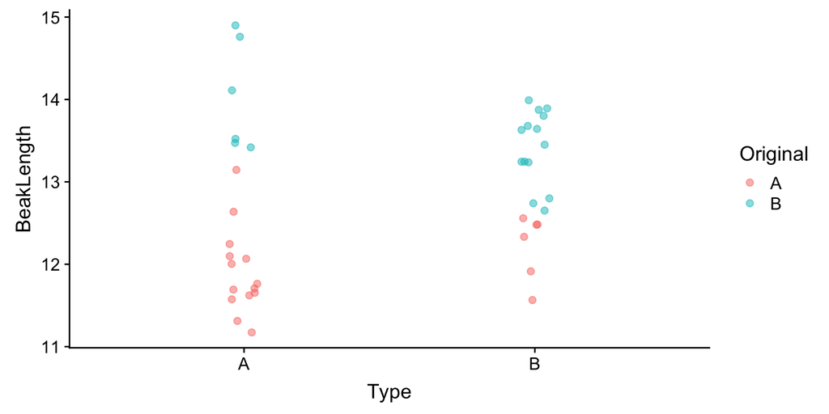

## Quiz 10-1

Lecture 10-2

## References

Felsenstein, J. 1985. Phylogenies and the Comparative Method. *American Naturalist* 125:1–15.

Felsenstein, J., and H. Kishino. 1993. Is There Something Wrong with the Bootstrap on Phylogenies? A Reply to Hillis and Bull. *Systematic Biology* 42:193–200. [Oxford University Press, Society of Systematic Biologists].

Ludbrook, J., and H. Dudley. 1998. Why Permutation Tests Are Superior to T and F Tests in Biomedical Research. *American Statistician* 52:127–132. [American Statistical Association, Taylor & Francis, Ltd.].

Manly, B. F. J. 2006. *Randomization, Bootstrap and Monte Carlo Methods in Biology*. 3rd edition. Chapman; Hall/CRC, Boca Raton, FL.

North, B. V., D. Curtis, and P. C. Sham. 2002. A Note on the Calculation of Empirical P Values from Monte Carlo Procedures. *American Journal of Human Genetics* 71:439–441.

Roff, D. A. 2002. Comparing G Matrices: A Manova Approach. *Evolution* 56:1286–1291.

Roff, D. A. 2008. Comparing Sire and Dam Estimates of Heritability: Jackknife and Likelihood Approaches. *Heredity* 100:32–38.

Roff, D. A. 2006. *Introduction to Computer-Intensive Methods of Data Analysis in Biology*. Cambridge University Press.

Roff, D. A., and R. Preziozi. 1994. The Estimation of the Genetic Correlation: The Use of the Jackknife. *Heredity* 73:544–548.